# 工具包安装与词云生成

**目标**：学习如何在 Anaconda Prompt 中安装 Python 工具包，并用 `wordcloud` + `matplotlib` 生成简单的英文词云图。

## 1. 安装工具包

在数据可视化和文本挖掘中，我们经常需要**第三方工具包**（package）。  
这里用到：

- **wordcloud**：生成词云图
- **matplotlib**：绘制图形

### 1.1 基本安装方法（在 Anaconda Prompt 中执行）

```
pip install wordcloud
pip install matplotlib
```

### 1.2 快捷安装方法（国内清华镜像源，加速下载）

```
pip install -i https://pypi.tuna.tsinghua.edu.cn/simple wordcloud
```

## 2. 导入工具包

安装完成后，在 Python 中用 `import` 导入：

- `matplotlib.pyplot as plt`：作图工具包
- `WordCloud, STOPWORDS`：词云和停用词集合

```python
import matplotlib.pyplot as plt   # 导入作图工具包
from wordcloud import WordCloud, STOPWORDS  # 导入词云工具、停用词工具
```

## 3. 读入语料

词云的输入通常是**一段文本**。这里用英文示例。  
也可以从文件读取，如 `open('text.txt').read()`。

```python
data = """Sometimes people come into your life and you know right away that they were meant to be there,
they serve some sort of purpose,to teach you a lesson or help figure out who you are or who you want to become.
You never know who these people may be -your roommate,neighbor,professor,long lost friend,lover or even a complete stranger
who,when you lockeyes with them,you know that very moment that they will affect your life in some profound way."""

# 查看前10个字符
print(data[:10])
```

```
Sometimes
```

## 4. 停用词（Stopwords）

停用词是在分析中需要忽略的常用词，如 `the`、`is`、`and` 等。  
`STOPWORDS` 是 `wordcloud` 自带的英文停用词集合，也可以添加自定义停用词。

```python
stopwords = set(STOPWORDS)
print("停用词样例：", list(stopwords)[:20])  # 查看部分停用词
```

```
停用词样例： ['the', 'how', 'is', "you're", 'above', 'have', 'below', 'what', 'while', 'during', 'from', "we've", 'each', "we'll", 'else', "hasn't", 'but', 'further', "they'd", "here's"]
```

## 5. 创建词云图

常用参数：

- `background_color`：背景颜色（如 `'white'`）
- `max_words`：最大显示的词数
- `stopwords`：停用词集合

生成方法：

```
wc = WordCloud(...)
wc.generate(data)
```

```python
wc = WordCloud(
    background_color='white',  # 背景颜色
    max_words=200,              # 最大显示词数
    stopwords=stopwords         # 停用词集合
)

wc.generate(data)  # 生成词云
```

```
<wordcloud.wordcloud.WordCloud at 0x28f7d536d60>
```

## 6. 绘制并显示词云

用 `matplotlib` 的 `imshow()` 显示词云图像。

- `interpolation="bilinear"` 让图像平滑
- `plt.axis("off")` 关闭坐标轴

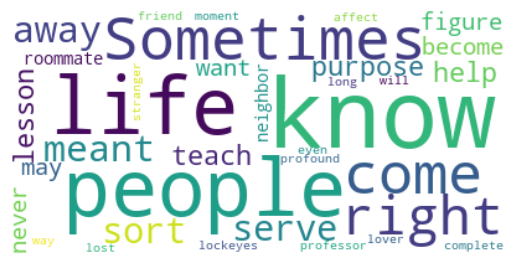

```python
plt.imshow(wc, interpolation="bilinear")
plt.axis("off")  # 不显示坐标轴
plt.show()
```

## 注意事项

1. **安装位置**：建议在 Anaconda Prompt（或终端）中执行 `pip install`，不要在 Python 交互环境里运行。
2. **中文词云**：如果文本是中文，需要先分词（如用 `jieba`），并指定支持中文的字体文件，否则会出现乱码。
3. **停用词调整**：可以用 `stopwords.add('word')` 添加额外停用词。
4. **文件输入**：大文本建议从 `.txt` 或 `.csv` 文件中读取，以便维护。